# Project : Communicate Data Findings

## Part II: Explanatory Data Analysis

Submitted by: Suraj Gurav

**Dataset: Ford GoBike System Data**

The required dataset is obtained from the [Source](https://s3.amazonaws.com/baywheels-data/index.html)

Here the monthwise data is available starting from January 2018 to May 2020. However, everything is updated on 10th Jan 2020. Going through some of the *.csv* files manually, I found that most of the data is missing from some files.

Hence, the selected data for this project is only **from January 2018 to March 2018**.

Before beginning the story, let me tell you the **Assumptions** that I considered..

1. The Ford GoBike System data only for January, February and March of 2018 is analysed
2. All types of *id* i.e. bike_id, start_station_id and end_station_id are integers

## Busiest time of the day

It is the time of day when maximum Ford GoBike trips start or end. For this busiest trip start hour and trip end hour are visualized.

In all the three months, the most of the bike trips start at 8:00 am and at 05:00 pm. Similar to the start hour, the end time for most of the trips in any month was 08:00 am and 05:00 pm. Even though these are the busiest times of day, In 1st two months of year, the time 08:00 is busier than 05:00 pm, where as this trend is reversed in month of March.

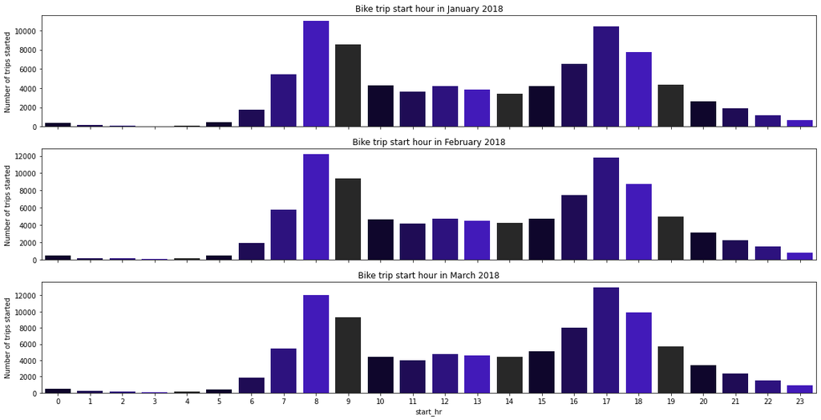

```python
timep=["#0C0032","#190061","#240090","#3500D3","#282828"]

f, (ax1, ax2, ax3) = plt.subplots(3, 1, figsize=[20,10], sharex=True)

sns.countplot(x = "start_hr", data = df.query("year_month == 1"), ax=ax1, palette = timep)
ax1.set_title("Bike trip start hour in January 2018");
ax1.set_xlabel("")
ax1.set_ylabel("Number of trips started");

sns.countplot(x = "start_hr", data = df.query("year_month == 2"), ax=ax2, palette = timep)
ax2.set_title("Bike trip start hour in February 2018");
ax2.set_xlabel("")
ax2.set_ylabel("Number of trips started");

sns.countplot(x = "start_hr", data = df.query("year_month == 3"), ax=ax3, palette = timep)
ax3.set_title("Bike trip start hour in March 2018");
ax3.set_ylabel("Number of trips started");
```

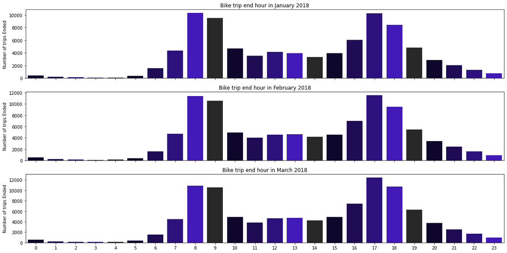

```python
timep=["#0C0032","#190061","#240090","#3500D3","#282828"]

f, (ax1, ax2, ax3) = plt.subplots(3, 1, figsize=[20,10], sharex=True)

sns.countplot(x = "end_hr", data = df.query("year_month == 1"), ax=ax1, palette = timep)
ax1.set_title("Bike trip end hour in January 2018");
ax1.set_xlabel("")
ax1.set_ylabel("Number of trips Ended");

sns.countplot(x = "end_hr", data = df.query("year_month == 2"), ax=ax2, palette = timep)
ax2.set_title("Bike trip end hour in February 2018");
ax2.set_xlabel("")
ax2.set_ylabel("Number of trips Ended");

sns.countplot(x = "end_hr", data = df.query("year_month == 3"), ax=ax3, palette = timep)
ax3.set_title("Bike trip end hour in March 2018");
ax3.set_xlabel("")
ax3.set_ylabel("Number of trips Ended");
```

## Age wise distribution of Ford GoBike users

Rather than visualizing the age of member, I made 5 age groups with the range of 10 years. It is observed that very few members have age more than 60 years, hence I created a new dataframe df_userage with all people with age less than or equal to 60 years.

Here I found the intersting data about members. 39% of the members belong to age group of 30 to 40 years and 33% member belong to age group of 20 to 30 years of age.

This means almost 72% of total members who are using Ford GoBike system are younger than 40 years

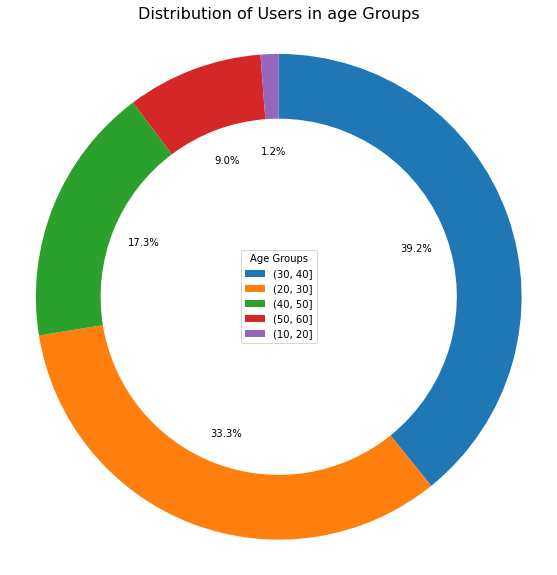

```python
fig, ax = plt.subplots(figsize = (10,10))
group_counts = df_userage["age_groups"].value_counts()
labels = group_counts.index
plt.pie(group_counts, startangle = 90,
        counterclock = False, wedgeprops = {'width' : 0.4}, autopct   = '%.1f%%', radius=1.5);
plt.title("Distribution of Users in age Groups", fontsize=16)
ax.legend(labels, title="Age Groups", loc="center")
plt.axis('square');
```

## Most frequent trip routes

Here, I explored the top 10 most frequently used GoBike trip routes. A route is defined as combination of a start station to a end station.

Route with start station id **15** to end station id **6** i.e. the route connecting San Francisco Ferry Building (Harry Bridges Plaza) to The Embarcadero at Sansome St looks more favorite for the bikers. It is used maximum 1238 times

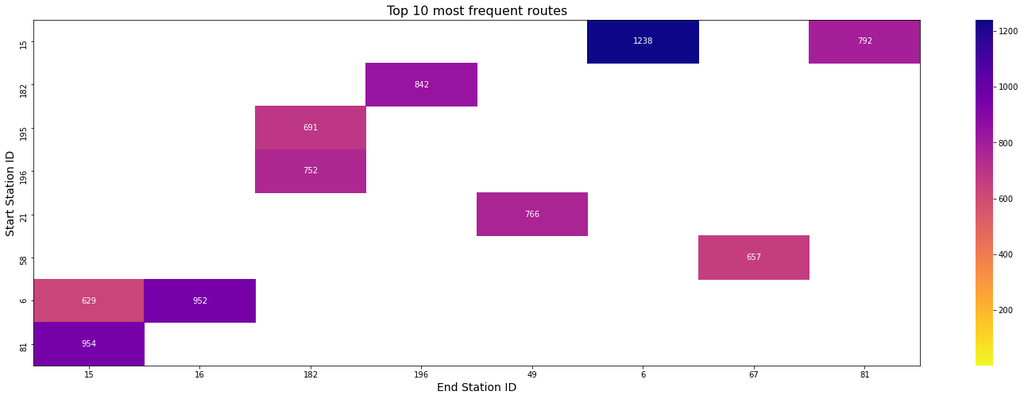

```python
routelist = df_route.bikeroute.value_counts().head(10).keys()
df_criteria = df_route[df_route["bikeroute"].isin(routelist)]
df_pivot = df_criteria.pivot_table(index="start_station_id", columns = "end_station_id", values = "start_time", aggfunc = "count", fill_value = 0)
fig, ax = plt.subplots(figsize = (25,8))
sns.heatmap(df_pivot, annot = True, cmap = "plasma_r", fmt='g', vmin = 1, vmax = 1240, mask= df_pivot == 0)
plt.title("Top 10 most frequent routes", fontsize=16);
plt.xlabel("End Station ID", fontsize=14);
plt.ylabel("Start Station ID", fontsize=14);
sns.despine(top=False, bottom=False, right=False, left=False)
```

## Ford GoBike trip duration distribution over the week

The average trip duration stays around 700 seconds i.e. approximately 12 minutes on weekdays. However, on weekends this average duration shoots up to around 900 to 1000 seconds.

Talking in terms of IQR (Inter-Quartile Range), the lowest IQR is observed on the Wednesday while the maximum IQR can be observed on weekends i.e. on Saturday and Sunday. In real world scenario the IQR can be understood as variation in data. So, on Wednesday, there is very less variation in the trip duration, whereas on weekends there is huge variation in the trip durations.

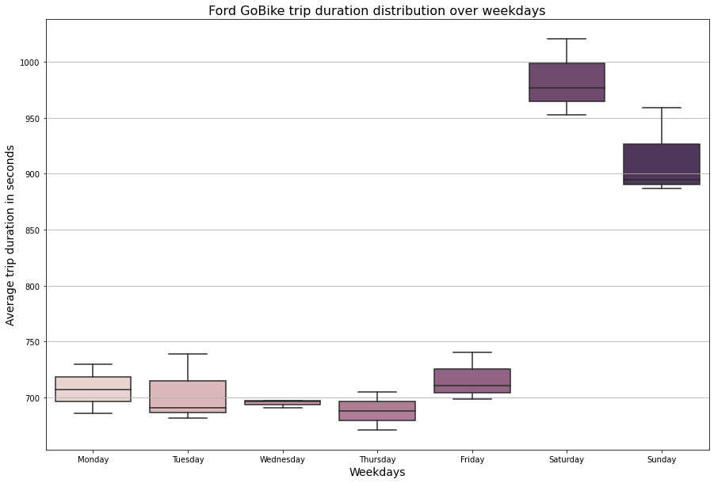

```python
fig, ax = plt.subplots(figsize = (15,10))
ax = sns.boxplot(x = "dayofweek", y = "duration_sec", data = df.groupby(["dayofweek", "year_month"], as_index = False).mean(), palette = sns.cubehelix_palette(8))
ax.set_xticklabels(["Monday","Tuesday","Wednesday","Thursday","Friday","Saturday","Sunday"])
ax.set_title("Ford GoBike trip duration distribution over weekdays", fontsize=16);
ax.set_xlabel("Weekdays", fontsize=14);
ax.set_ylabel("Average trip duration in seconds", fontsize=14);
plt.grid(which='major', axis='y');
```

## Ford GoBike trip duration distribution over age of the user

The trip duration shows decreasing trend as we increase the age upto 40 years old and then duration starts increasing again beyond this age group. Teens of age group 10 to 20 like to use GoBike for longer duration. The people in age group 30 to 40 years old, resulted in smallest duration of trip.

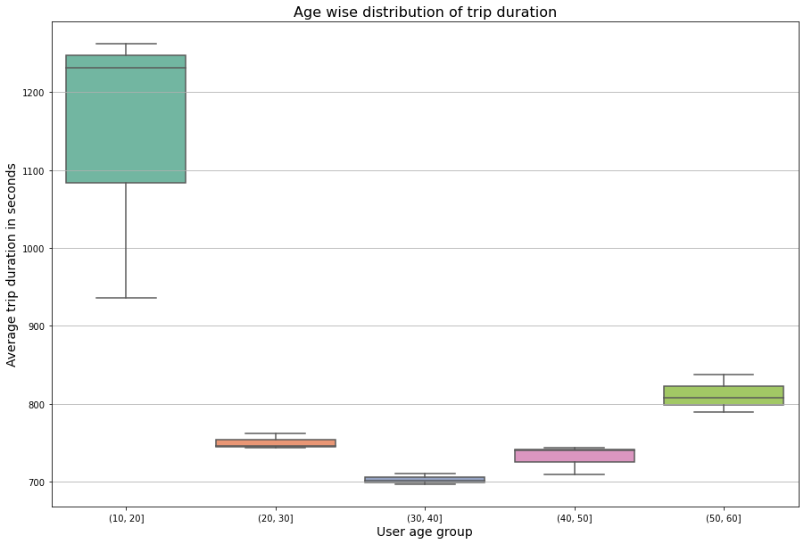

```python
fig, ax = plt.subplots(figsize = (15,10))
ax = sns.boxplot(x = "age_groups", y = "duration_sec", data = df_userage.groupby(["age_groups","year_month"], as_index = False).mean(), palette = "Set2")
ax.set_title("Age wise distribution of trip duration", fontsize=16);
ax.set_xlabel("User age group", fontsize=14);
ax.set_ylabel("Average trip duration in seconds", fontsize=14);
plt.grid(which='major', axis='y');
```

## Ford GoBike trip duration distribution over start and end time in a day

This is the example of multivariate exploration. The darker pattern along the diagonal of the graph highlights that, most of of the trips start and end within the same hour. As we move away from the diagonal, lighter markers can be observed, which means that, there were few trips with long durations.

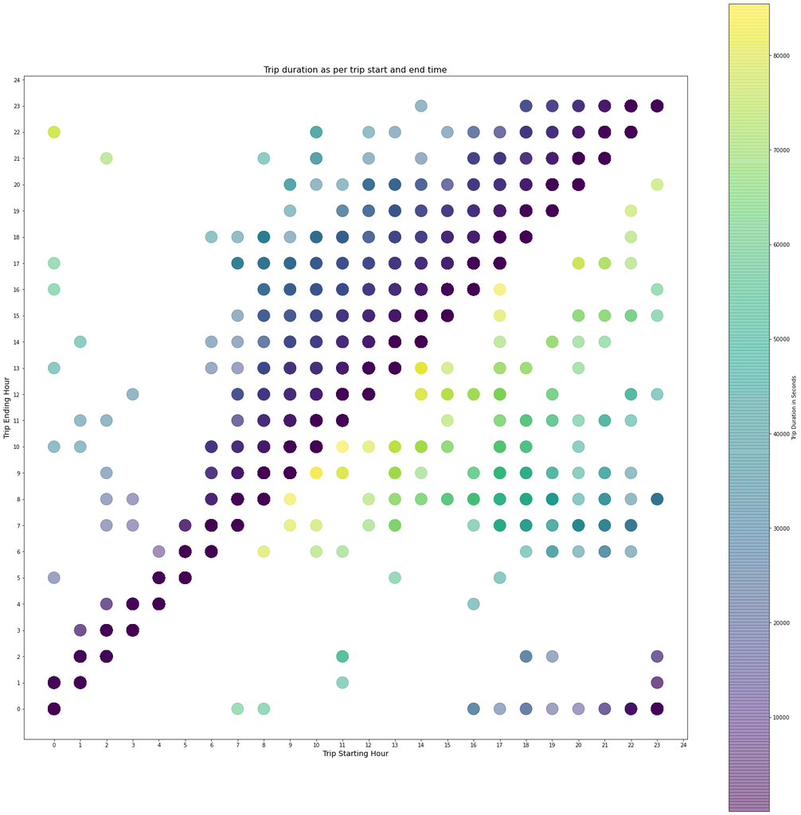

```python
fig, ax = plt.subplots(figsize = (28,28))
plt.scatter(x="start_hr", y="end_hr", c="duration_sec", s=500, data=df_userage, alpha=0.5)
ax.set_xticks(np.arange(0, 25, step=1));
ax.set_yticks(np.arange(0, 25, step=1));
ax.set_xlabel("Trip Starting Hour", fontsize=14);
ax.set_ylabel("Trip Ending Hour", fontsize=14);
ax.set_title("Trip duration as per trip start and end time", fontsize=16);
plt.colorbar(label="Trip Duration in Seconds");
plt.axis('square');
```